# index

## An Analysis of Arctic Sea Ice

By: Luke Wichrowski

### Introduction

The Arctic region is one of the most sensitive regions to climate change, with the most visible impact being the decline in sea ice. Arctic sea ice is a vital component of Earth's ecosystem and plays a significant role in regulating Earth’s climate. The recent decline in arctic sea ice levels has caused significant impacts on the environment and wildlife across the planet. That’s why we need to understand arctic sea ice, what has caused its decline, and the effects of its melting.

Throughout this tutorial, we will be analyzing Arctic sea ice extent by following the Data Science Lifecycle.

```
1. Data Collection
2. Data Processing
3. Exploration and Visualization
4. Model: Analysis and Machine Learning
5. Interpretation
```

### Data Collection

The first part of the data science lifecycle is data collection. During this stage, we need to find comprehensive and trustworthy datasets on arctic sea ice and related topics. We will be using four different sets of data from three different sources.

Since we will be looking at Arctic sea ice the first dataset will be monthly Arctic sea ice extent data from the National Snow and Ice Data Center. The dataset is stored as an Excel spreadsheet named “Sea_Ice_Index_Monthly_Data_by_Year_G02135_v3.0.xlsx” and can be found on NSIDC’s website [here](https://masie_web.apps.nsidc.org/pub/DATASETS/NOAA/G02135/seaice_analysis/).

The second set of data we will use comes from the National Oceanic and Atmospheric Administration, and it is their monthly climate indicators. These are sets of climate measurements from multiple different regions around the world that are used to monitor and analyze changes in the climate. NOAA has many of these climate indicators on its [website](https://psl.noaa.gov/data/climateindices/list/#AO).

The next dataset also comes from NOAA. It is the sea surface temperature (SST) of the water in the Arctic. It contains monthly data from September 1981 to March 2023. This data is gridded, meaning it contains a regular grid of points every quarter degree latitude and longitude covering the Arctic region, each containing the SST at that location. This is a lot of data, the file is 438 MB, but it will be useful for finding the average SST over different regions of the Arctic. The data can be downloaded from the NOAA [website](https://psl.noaa.gov/mddb2/makePlot.html?variableID=156646&fileID=1242246) after selecting “Create Composite”, setting it to the max time frame, and selecting “Arctic” as the region.

The final set of data we will use is from the ERA5 dataset which is the latest climate reanalysis produced by the [European Centre for Medium-Range Weather Forecasts](https://www.ecmwf.int/) and can be found on the [Climate Data Store](https://cds.climate.copernicus.eu/cdsapp#!/home). We will need the temperature at different pressure levels over the Arctic region from 1979 to 2023. These options can be chosen on the CDS [website](https://cds.climate.copernicus.eu/cdsapp#!/dataset/reanalysis-era5-pressure-levels-monthly-means?tab=form) and a request to download the data can be sent.

##### Imports

Throughout this tutorial we will be using python and many of its useful libraries which we will import below.

```python
#Data processing
import numpy as np
import pandas as pd
import xarray as xr
import datetime as dt
#Plotting
import matplotlib.pyplot as plt
from matplotlib import cm
from mpl_toolkits.basemap import Basemap
#Data wrangling
import requests
from bs4 import BeautifulSoup
#Machine learning
from sklearn.linear_model import LinearRegression
from sklearn.model_selection import train_test_split
from sklearn.preprocessing import StandardScaler
from sklearn.ensemble import RandomForestRegressor

monthNames = ["Jan", "Feb", "Mar", "Apr", "May", "Jun", "Jul", "Aug", "Sep", "Oct", "Nov", "Dec"]
```

The main library that we will be using is [Pandas](https://pandas.pydata.org/), it is an open-source data analysis library built on top of the [Numpy](https://numpy.org/) library that offers multiple data structures for storing and manipulating data easily.

We will also be using [Matplotlib](https://matplotlib.org/) for creating all of our visualizations and graphs, it is also built on top of Numpy allowing it to work well with Pandas.

### Data Processing

We will start off our data processing with the Sea Ice extent dataset. This is stored in an Excel spreadsheet which pandas luckily has a function that reads in Excel files and converts the data into a DataFrame for us. Although this function does not store the data in the DataFrame the way we need it to be stored, so we will have to process it.

The Excel spreadsheet has rows for each year of data and columns for each month in the year. Using pd.melt() we can combine all month columns into one to simplify the DataFrame. Then we can convert the year and month variables into datetime objects which will make processing the data much easier in the future.

We now have the Arctic sea ice extent for every month and year from 1978-2023. This is good but we will also want to the at the sea ice anomalies, which we will have to calculate on our own. Climate anomalies are calculated by taking the difference between the observed values and the climate average. Climate averages are calculated over 30-year periods, so we will use the years 1978 to 2008 to calculate each month's average Arctic sea ice extent.

```python
#Read in just the first sheet from the excel spreadsheet
icedf = pd.read_excel("Sea_Ice_Index_Monthly_Data_by_Year_G02135_v3.0.xlsx", 0)
#Make the year column into the index
icedf.index = icedf.iloc[:,0]
#Rename it to time
icedf.index.name = "time"
#Drop extra columns
icedf = icedf.drop(columns= ["Unnamed: 0", "Unnamed: 13", "Annual"])
#Melt the month columns into one column for the month
icedf = icedf.melt(var_name= "month", value_name= "extent", ignore_index= False)
#Convert month names into their number
icedf["month"] = icedf["month"].apply(lambda x: dt.datetime.strptime(x, "%B").month)
#Convert the index into a datetime object with the year and month
icedf.index = pd.to_datetime(icedf.index.astype(str) + " " + icedf["month"].astype(str) + " 1", format= "%Y %m %d")

#Drop any months with no data
icedf = icedf.dropna()
#Sort index into cronological order
icedf = icedf.sort_index()
#Subset with only values from Nov 1978 to Nov 2008 for a 30 year climate average
averages = icedf[icedf.index <= "2008-11-01"]
#Group by the month and find the average for each month
averages = averages.groupby(averages.index.month).mean()
#Change column name to average
averages.columns = ["month", "average"]
#Save original dfs index to reindex after the merge
icedfindex = icedf.index
#Merge averages into the original df
icedf = icedf.merge(averages, how= "left", on= "month").set_index(icedfindex)
#Calculate the anomaly
icedf["anom"] = icedf["extent"] - icedf["average"]
icedf["year"] = icedf.index.year

display(icedf)
```

|  | month | extent | average | anom | year |
| --- | --- | --- | --- | --- | --- |
| 1978-11-01 | 11 | 11.645 | 10.826129 | 0.818871 | 1978 |
| 1978-12-01 | 12 | 13.667 | 12.984621 | 0.682379 | 1978 |
| 1979-01-01 | 1 | 15.414 | 14.511310 | 0.902690 | 1979 |
| 1979-02-01 | 2 | 16.175 | 15.392233 | 0.782767 | 1979 |
| 1979-03-01 | 3 | 16.342 | 15.503133 | 0.838867 | 1979 |
| ... | ... | ... | ... | ... | ... |
| 2022-11-01 | 11 | 9.712 | 10.826129 | -1.114129 | 2022 |
| 2022-12-01 | 12 | 11.917 | 12.984621 | -1.067621 | 2022 |
| 2023-01-01 | 1 | 13.346 | 14.511310 | -1.165310 | 2023 |
| 2023-02-01 | 2 | 14.176 | 15.392233 | -1.216233 | 2023 |
| 2023-03-01 | 3 | 14.440 | 15.503133 | -1.063133 | 2023 |

531 rows × 5 columns

Now we will start processing the NOAA climate indices. These are stored on NOAA's website so we will have to scrape the data off of the web, store it in a DataFrame, and process it. Each index is stored in a table like the Sea Ice Extent data with rows of years and columns of months, so we will have to melt each of these tables into a singular column again. We will then use pd.concat() to combine each of these columns into one larger DataFrame.

```python
climateIdx = ["pna", "wp", "nao", "soi", "nina3.anom", "censo", "tna",
              "tsa", "whwp", "nina1.anom", "nina4.anom", "nina34.anom",
              "ao", "aao", "amon.us", "qbo"]

#List of dataframes that will be merged together
dfs = []
#Each index uses a different number to signify missing data. Store each of them
empty = set()
#Loop through each index that we need
for idx in climateIdx:
    #Send a request to the webpage
    r = requests.get("https://psl.noaa.gov/data/correlation/" + idx + ".data")
    #Clean the html
    soup = BeautifulSoup(r.content, 'html.parser')
    #Split the data by each row
    data = soup.text.split("\n")
    #Year range is stored in the first line
    years = data[0].split()
    #Calculate the range
    yearRange = int(years[1]) - int(years[0]) + 1
    #Row after the last data row contains the missing data symbol. Add it to the set
    empty.add(float(data[yearRange + 1].strip()))
    #Make the data into a 2D array and convert into a dataframe
    df = pd.DataFrame([x.split() for x in data[1:yearRange + 1]])
    #The First column stores the year, which will be used as an index
    df.index = df[0]
    #Get rid of the year column
    df.drop(columns = [0], inplace= True)
    #Melt dataset to get the month columns into one
    df = pd.melt(df, ignore_index= False, var_name= "month", value_name= idx)
    #Convert index into a date time with the year and month
    df.index = pd.to_datetime(df.index + " " + df["month"].astype(str) + " 1", format= "%Y %m %d")
    #Drop month column
    df.drop(columns= ["month"], inplace= True)
    #Add to list of dataframes
    dfs.append(df)

#Concatenate all dfs
climatedf = pd.concat(dfs, axis= 1)
#Convert data from strings to floats
climatedf = climatedf.astype(float)
#Replace all entries with missing data with numpy NaN
climatedf.replace(empty, np.nan, inplace= True)
#Drop all rows with missing data
climatedf = climatedf.dropna()
display(climatedf)
```

|  | pna | wp | nao | soi | nina3.anom | censo | tna | tsa | whwp | nina1.anom | nina4.anom | nina34.anom | ao | aao | amon.us | qbo |
| --- | --- | --- | --- | --- | --- | --- | --- | --- | --- | --- | --- | --- | --- | --- | --- | --- |
| 1979-01-01 | -1.54 | 1.43 | -2.12 | -0.7 | -0.32 | 0.26 | 0.17 | -0.16 | -0.17 | 0.16 | 0.04 | -0.13 | -2.233 | 0.209 | -0.205 | 1.86 |
| 1979-02-01 | -2.73 | -0.66 | -1.20 | 1.6 | -0.29 | -0.25 | 0.28 | -0.24 | -0.23 | -0.58 | -0.11 | -0.22 | -0.697 | 0.356 | -0.164 | 4.12 |
| 1979-03-01 | 0.08 | -0.29 | 0.41 | 0.2 | -0.06 | 0.32 | 0.15 | -0.31 | -0.73 | -0.58 | -0.02 | -0.02 | -0.814 | 0.899 | -0.241 | 0.89 |
| 1979-04-01 | -0.15 | 0.85 | -2.01 | -0.2 | 0.07 | 0.47 | 0.29 | 0.01 | -0.02 | 0.15 | -0.02 | 0.02 | -1.157 | 0.678 | -0.250 | -3.57 |
| 1979-05-01 | 1.27 | -0.13 | -0.90 | 0.8 | -0.05 | -0.18 | 0.35 | 0.07 | -0.52 | -0.13 | -0.18 | -0.25 | -0.250 | 0.724 | -0.130 | -12.90 |
| ... | ... | ... | ... | ... | ... | ... | ... | ... | ... | ... | ... | ... | ... | ... | ... | ... |
| 2022-08-01 | 0.76 | -0.41 | 1.76 | 1.7 | -0.67 | -1.52 | 0.47 | 0.38 | 4.12 | -0.60 | -1.09 | -0.98 | -0.170 | 0.731 | 0.358 | 7.87 |
| 2022-09-01 | 0.13 | 1.82 | -1.42 | 2.7 | -0.96 | -1.87 | 0.62 | 0.35 | 4.31 | -1.02 | -1.17 | -1.07 | -0.655 | 1.469 | 0.662 | 9.80 |
| 2022-10-01 | 0.35 | 1.04 | -0.27 | 2.8 | -1.10 | -1.78 | 0.50 | 0.52 | 4.74 | -1.79 | -1.12 | -0.98 | 1.346 | 0.330 | 0.483 | 10.93 |
| 2022-11-01 | -0.71 | 0.34 | 0.59 | 0.5 | -0.94 | -0.62 | 0.33 | 0.51 | 1.71 | -1.13 | -0.99 | -0.90 | 0.339 | 1.713 | 0.282 | 12.45 |
| 2022-12-01 | -0.96 | -0.02 | -0.22 | 3.5 | -0.81 | -2.01 | 0.47 | 0.60 | -0.01 | -0.46 | -0.84 | -0.85 | -2.719 | 1.700 | 0.218 | 11.70 |

528 rows × 16 columns

Now for the sea surface temperature dataset. This is stored in a netCDF file format which is effective for storing and analyzing large multidimensional datasets and is very commonly used in atmospheric and oceanic research. Since we are already using pandas to store and process our data we will use the xarray package to read the data from the file and then convert it into a DataFrame for us. We will create locational subsets of this DataFrame and then average the SST over all locations in the subsets to track the SST in different Arctic regions over time.

```python
#Open the netCDF file with xarray
da = xr.open_dataset("Arctic_SST.nc")
#Convert the xarray into a dataframe
sstdf = da.to_dataframe()
#Turn the multidimentional index into multiple columns
sstdf = sstdf.reset_index()

#List of regions with their latitude and longitude bounds
regions = [("gin", 60, 80, -30, 20,), ("barents", 60, 80, 20, 60),
           ("labrador", 60, 70, -65, -50), ("bering", 60, 75, -180, -160)]
regiondfs = []

#Loop through each region
for region in regions:
    #Subset the dataframe with only data within the given lat and lon
    df = sstdf[(region[3] <= sstdf["lon"]) & (sstdf["lon"] <= region[4])]
    df = df[(region[1] <= df["lat"]) & (df["lat"] <= region[2])]
    #Average SST over the region
    df = df.groupby("time").mean()
    #Drop lat and lon columns
    df = df.drop(columns= ["lon", "lat"])
    #Rename column to region name
    df.columns = [region[0]]
    regiondfs.append(df)

#Contatenate all of the regions into one df
sstregions = pd.concat(regiondfs, axis= 1)
display(sstregions)
```

| time | gin | barents | labrador | bering |
| --- | --- | --- | --- | --- |
| 1981-09-01 | 5.806074 | 4.238778 | 3.599850 | 3.126422 |
| 1981-10-01 | 4.396895 | 2.732133 | 1.971074 | 1.578907 |
| 1981-11-01 | 3.541234 | 1.345186 | 0.454718 | -0.380689 |
| 1981-12-01 | 2.889400 | 0.220535 | -0.147476 | -1.133646 |
| 1982-01-01 | 2.586265 | -0.486170 | -0.261323 | -1.276087 |
| ... | ... | ... | ... | ... |
| 2022-11-01 | 4.830947 | 2.753937 | 1.040717 | 0.350257 |
| 2022-12-01 | 4.199428 | 1.771400 | 0.487598 | -0.768230 |
| 2023-01-01 | 3.595629 | 1.040384 | -0.154598 | -1.403942 |
| 2023-02-01 | 3.318407 | 0.893721 | -0.548450 | -1.541509 |
| 2023-03-01 | 2.944577 | 0.491979 | -0.411354 | -1.565566 |

499 rows × 4 columns

Lastly we have the air temperature dataset to process. The processing will be very similar to SST dataset, the main difference is there is now 4 different pressure levels that the temperature is recorded at. Due to the size of the data we will seperately convert the xarray into 4 different DataFrames one for each pressure level. We will find the climate average for each pressure level based on the years 1979-2008, and calculate the temperature anomaly.

```python
#Open up the NetCDF file and put each pressure level into its own dataframe
da = xr.open_dataset("Temperature.nc")
t1000df = da.isel(level= 3, number= 0).to_dataframe()
t850df = da.isel(level= 2, number= 0).to_dataframe().groupby("time").mean()
t500df = da.isel(level= 1, number= 0).to_dataframe().groupby("time").mean()
t200df = da.isel(level= 0, number= 0).to_dataframe().groupby("time").mean()

#Turn multiIndex into columns
t1000df = t1000df.reset_index()
#Make time the new index
t1000df.index = t1000df["time"]
#Drop unneeded columns
t1000df = t1000df.drop(columns= ["number", "level"])
#Add a month column for qeasier merging
t1000df["month"] = t1000df.index.month
#Take the climate average from the years 1979-2008
averages = t1000df[t1000df.index <= "2008-12-01"]
averages = averages.groupby(["latitude", "longitude", "month"]).mean()
#Rename the column
averages.columns = ["average"]
#Merge the two dataframes together
t1000df = t1000df.merge(averages, how= "left", on= ["latitude", "longitude", "month"])
#Find the anomaly for each month and location
t1000df["anom"] = t1000df["t"] - t1000df["average"]
#Reset the index as the time
t1000df.index = t1000df["time"]
t1000df = t1000df.drop(columns= ["time", "month"])


#Concat other dataframes into one
tdf = pd.concat([t850df, t500df, t200df])
tdf = tdf.drop(columns= ["number"])
#Create new month column to make merging easier later
tdf["month"] = tdf.index.month
#Find the climate average over the 30 years 1979-2008
averages = tdf[tdf.index <= "2008-12-01"]
averages = averages.groupby(["month", "level"]).mean()
#Rename to average
averages.columns = ["average"]
#Make new time column so indicies are remembered
tdf["time"] = tdf.index
#Merge averages back into the original df
tdf = tdf.merge(averages, how= "left", on= ["month", "level"])
tdf.index = tdf["time"]
#Drop now unneed columns
tdf = tdf.drop(columns = ["time", "month"])
#Find the anomally for each month
tdf["anom"] = tdf["t"] - tdf["average"]
display(tdf)
```

| time | level | t | average | anom |
| --- | --- | --- | --- | --- |
| 1979-01-01 | 850.0 | 253.666824 | 253.700684 | -0.033859 |
| 1979-02-01 | 850.0 | 249.263794 | 253.601913 | -4.338120 |
| 1979-03-01 | 850.0 | 254.907745 | 254.858673 | 0.049072 |
| 1979-04-01 | 850.0 | 256.718781 | 258.728668 | -2.009888 |
| 1979-05-01 | 850.0 | 264.523285 | 264.902496 | -0.379211 |
| ... | ... | ... | ... | ... |
| 2022-08-01 | 200.0 | 226.117691 | 226.391556 | -0.273865 |
| 2022-09-01 | 200.0 | 224.409500 | 223.889893 | 0.519608 |
| 2022-10-01 | 200.0 | 221.895035 | 220.752686 | 1.142349 |
| 2022-11-01 | 200.0 | 217.352783 | 216.813370 | 0.539413 |
| 2022-12-01 | 200.0 | 213.482574 | 213.803787 | -0.321213 |

1584 rows × 4 columns

### Data Exploration and Visualization

Finally we have all of our data processed and cleaned. That means we can start our data exploration and visualization. Let's start off by visualizing the Arctic sea ice extent.

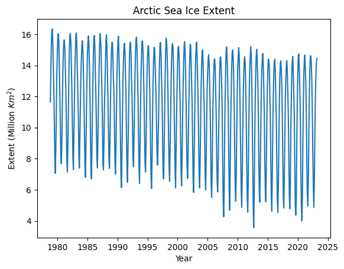

```python
#Plots the extent over time
ax = plt.plot(icedf["extent"])
plt.xlabel("Year")
plt.ylabel("Extent (Million $Km^{2}$)")
plt.title("Arctic Sea Ice Extent")
plt.show()
```

As you can see the graph is quite volatile and fluctuates periodically, but has a downward trend over the years. The repeated cycle is because of the Arctic sea ice yearly fluctuations from the seasons. Lets look more into this by graphing each years extent over the 12 months.

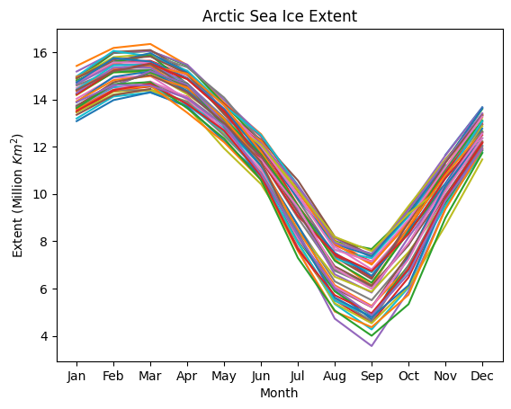

```python
fig, ax = plt.subplots()
#For each year plot the extent over the 12 months
for key, grp in icedf.groupby(icedf.index.year):
    ax = grp.plot(ax= ax, x= "month", y= "extent", legend= False)
plt.xlabel("Month")
plt.ylabel("Extent (Million $Km^{2}$)")
plt.title("Arctic Sea Ice Extent")
#Replace labels with month names
plt.xticks(range(1,13), monthNames)
plt.show()
```

Now we can clearly see how the yearly sea ice cycle works. Sea ice extent peaks in March and hits its minimum in September every year. There appears to be a large variance at the extent minimum compared with every other time of year. Since we have almost 45 years of extent data it causes all of the lines to be clustered ontop of each other, which makes seeing the distribution hard to see. For the next visualization we will graph some of the percentiles of the extent and compare it against the extent from 2020.

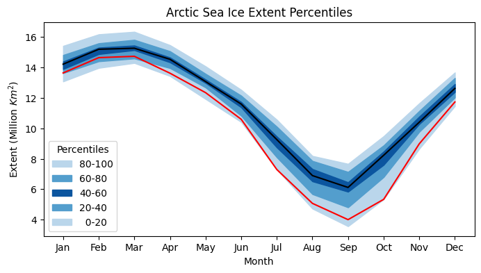

```python
#Pivot the original df into a new one
icepercent = pd.pivot_table(icedf, values= "extent", index= icedf.index.month, columns= icedf.index.year)
#Sort the dataframe by index
icepercent = icepercent.sort_index()

#Array of the percentiles we will look at
percentiles = [0, 20, 40, 50, 60, 80, 100]
#Get the number of percentiles
n = len(percentiles)
#New dataframe that will store the values at each percentile at each month
SDist = pd.DataFrame(index= range(1,13))
#Loop through each percentile
for i in range(n):
    percent = np.zeros(12)
    #For each month find the value of the given percentile
    for j in range(12):
        percent[j] = np.percentile(icepercent.iloc[j, :].dropna(), percentiles[i])

    #Add the percentile list onto a new row of the dataframe
    SDist[percentiles[i]] = percent

colormap = cm.Blues
fig1, ax = plt.subplots(figsize= (8, 4))
#Array to save the plots to be labeled
plot = [None] * int((n)/2)
#Loop through half of the percentiles
for i in range(int((n)/2)):
    #Fill between each corresponding percentile with a different color
    plot[i] = ax.fill_between(SDist.index, SDist.iloc[:, i], SDist.iloc[:, -(i + 1)], color= colormap((i + 1)/((n)/2)))

#Plot the median in black
ax.plot(SDist.iloc[:, int(n/2)], color = "black")
plt.xticks(range(1,13), monthNames)
ax.plot(icepercent.loc[:, 2020], color= "red", label= "2020")

#Label the graph
ax.set_xlabel("Month")
ax.set_ylabel("Extent (Million $Km^{2}$)")
ax.set_title("Arctic Sea Ice Extent Percentiles")
#Create legend
plot = plot + plot[1::-1]
ax.legend(plot, ["80-100", "60-80", "40-60", "20-40", "  0-20"], loc= "lower left", title= "Percentiles")
plt.show()
```

With the percentiles now shown we can see how the extent from 2020 stayed solidly in the 0-20 percentile range for almost the entire year. This is just one year so it can be hard to tell if it just happened to be a fluke year or if this is part of a greater trend in sea ice extent. To figure this out we can plot the extent anomaly that we calculated during the data processing stage and look for trends in it.

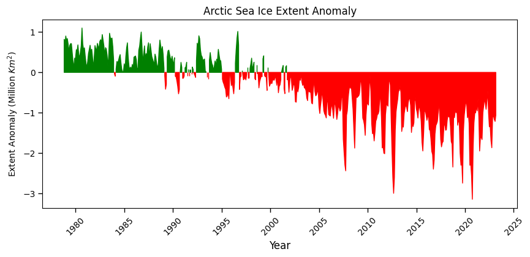

```python
#Seperate out the data we need and convert to float
anomdf = icedf["anom"].astype(float)

#Plot the graph with coloring in green for positive, and red for negative
plt.figure(figsize= (10, 4))
plt.fill_between(anomdf.index, anomdf.values, 0, where= anomdf.values > 0, color= "g")
plt.fill_between(anomdf.index, anomdf.values, 0, where= anomdf.values <= 0, color= "r")

#Edit all of the graph labels to be more visible
plt.tick_params(axis= "both", length= 5, width= 1)
plt.xticks(fontsize= 10, rotation= 45)
plt.yticks(fontsize= 10)
plt.xlabel("Year", fontsize= 12)
plt.ylabel("Extent Anomaly (Million $Km^{2}$)", fontsize= 10)
plt.title("Arctic Sea Ice Extent Anomaly", fontsize= 12)
plt.show()
```

Looking at this graph it is very clear that there is a strong trend in Arctic sea ice. The extent anomaly seems to spike sharply negative frequently in the the past 15 years, and the spikes seem to line up with about one every year. This observation is consistent with the data we saw in the previous graph with the extent in September having greater variance, lower minimums, and thus larger negative anomalies. Therefore there is the trend of sea ice extent dwindling, but there also seems to be an even stronger trend in september sea ice extent decreasing at a faster rate. We will look into this more later.

When processing the temperature data we did not average the 1000 hPa data across the location, so we still have it in a gridded format. With this we can not plot a contour map of the temperature anomaly to see which regions are hotter or colder than average.

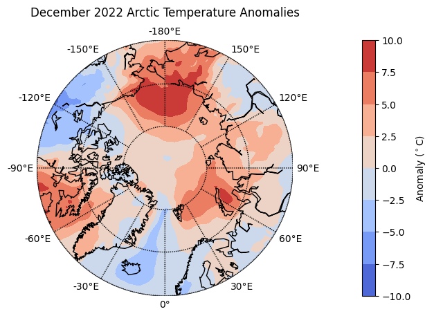

```python
#Subset with only data from December 2022
#Pivot the subset so that columns are longitude and rows are latitude
mapdf = pd.pivot_table(t1000df[t1000df.index == "2022-12-01"], "anom", "latitude", "longitude")

#Create a meshgrid of the latitudes and longitudes
x, y = np.meshgrid(list(mapdf.columns), list(mapdf.index))

#Create map with North Pole Sterographic Projection
map = Basemap(boundinglat= 60, lon_0= 0, projection= "npstere", round= True)
#Draw coastlines and latitude and longitude lines
map.drawcoastlines()
map.drawmeridians(np.arange(-180.,180.,30.), labels= [True, True, True, True])
map.drawparallels(np.arange(60.,91.,10.), labels= [True, True, True, True])
#Create the temp anom contour
map.contourf(x, y, mapdf, latlon= True, cmap= "coolwarm")
#Display colorbar on the side
cbar = map.colorbar(pad= 1)
plt.title("December 2022 Arctic Temperature Anomalies", pad= 25)
cbar.set_label("Anomaly ($^\circ$C)")
```

While there are still some locations with colder than average temperature there's more locations with a positive anomaly and the positive anomalies tend to be larger. The warmer areas are also centered over areas that have a majority of the Arctic sea ice or near the edge of the extent.

Now lets finish processing the 1000 hPa data and then plot all of the temperature anomalies over time to see how they change.

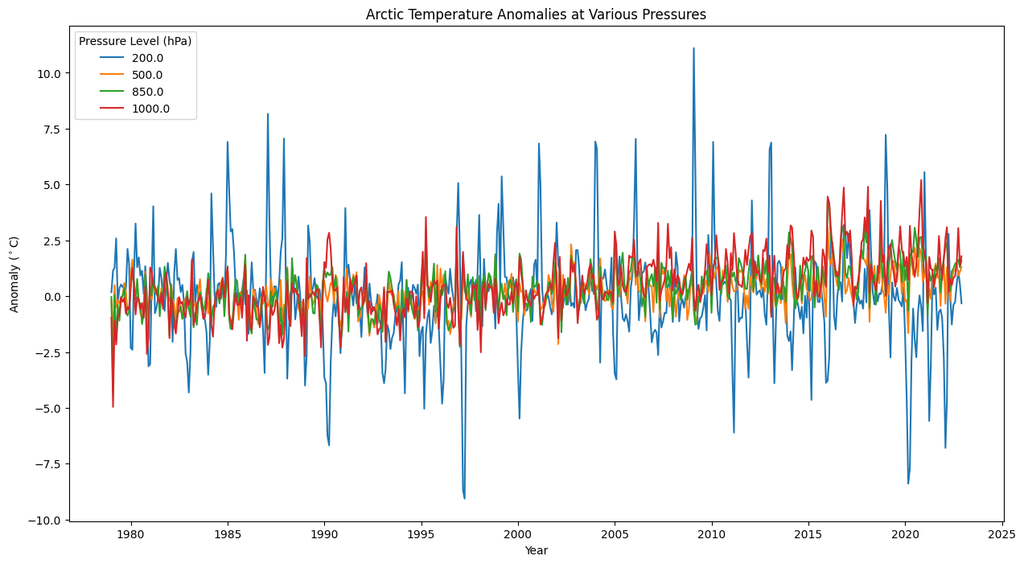

```python
#Average the temperature over all locations
t1000df = t1000df.groupby(t1000df.index).mean()
#Drop lat and lon columns
t1000df = t1000df.drop(columns= ["latitude", "longitude"])
#Concatenate into df with other pressure level temps
tdf = pd.concat([tdf, t1000df])
tdf = tdf.fillna(1000)

#Create the plot
fig, ax = plt.subplots(figsize= (15, 8))
groups = tdf.groupby("level")
plot = []

#For each pressure level plot the anomaly
for name, group in groups:
    plt.plot(group["anom"], label= name)

ax.legend(loc= "upper left", title= "Pressure Level (hPa)")
plt.title("Arctic Temperature Anomalies at Various Pressures")
plt.xlabel("Year")
plt.ylabel("Anomaly ($^\circ$C)")
plt.show()
```

There does seem to be a slight positive trend in the temperature over time, which could be correlated with the loss of sea ice that the Arctic has been experiancing. We will explore this trend more with linear regression in the next section.

### Analysis and Machine Learning

Now that we have a solid understanding of our data we can start to use machine learning to analize it even better. The first machine learning algorithm we will use is linear regression, it is an algorithm that will find the best fit line for a set of data. It does this through minimizing the the square of the error from each point to the line. One great use of linear regression is finding linear trends in data, so let's use it to find the trend in Arctic sea ice.

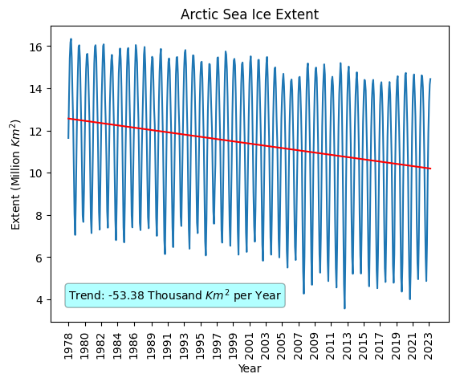

```python
fig, ax = plt.subplots()

#New dataframe with just the extent data
regdf = icedf["extent"].dropna()
#Convert datetime into int for regression
years = regdf.index.map(dt.datetime.toordinal)
#Fit the regression model
reg = LinearRegression().fit(years.array.reshape(-1, 1), regdf.values)
#Plot the original data
ax.plot(years, regdf)
#Plot the regression line
ax.plot(years, reg.intercept_ + reg.coef_ * years, color= "red")
#Convert the xticks to label the year for every other year
plt.xticks(years[::24], years[::24].map(dt.datetime.fromordinal).year, rotation= "vertical")
plt.xlabel("Year")
plt.ylabel("Extent (Million $Km^{2}$)")
plt.title("Arctic Sea Ice Extent")
#Find the trend per year and display it
ax.text(years[0], 4, "Trend: " + str(reg.coef_[0] * 365000)[:6] + " Thousand $Km^{2}$ per Year",
        bbox= dict(boxstyle= "round", facecolor= "cyan", alpha= .3))
plt.show()
```

Having the regression line plotted on top of the extent data helps to show continuous loss of Arctic sea ice. After fitting the data to the regression model finding the trend is as easy as looking at the coefficient of the regression line. After converting the coefficient into the proper units we find that we are losing on average 53.38 thousand square kilometers of sea ice every year. But as we have determined earlier in this tutorial there seems to be a trend in september sea ice extent declining more rapidly. Let's run another linear regression model but only on September extent this time.

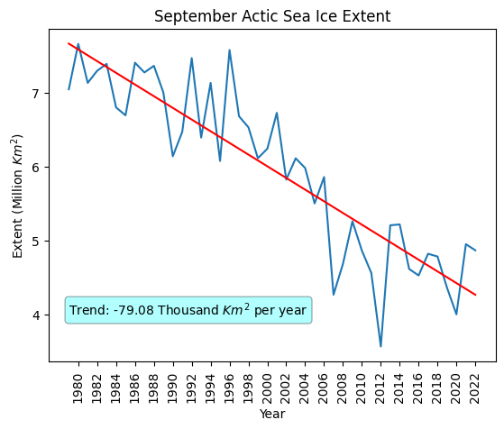

```python
#Subset with only the extent for each September
mindf = icedf[icedf["month"] == 9]["extent"]

#Convert datetime into an integer for regression
years = mindf.index.map(dt.datetime.toordinal)

#Plot the original data
plt.plot(years, mindf.values)
#Fit the regression model
reg = LinearRegression().fit(years.array.reshape(-1,1), mindf.values)
#Plot the regression line
plt.plot(years, years * reg.coef_ + reg.intercept_, color= "red")
#Convert xticks to display just the year for every other year
plt.xticks(years[1::2], years[1::2].map(dt.datetime.fromordinal).year, rotation= "vertical")
plt.xlabel("Year")
plt.ylabel("Extent (Million $Km^{2}$)")
plt.title("September Actic Sea Ice Extent")
#Calculate the trend per year and display it
plt.text(years[0], 4, "Trend: " + str(reg.coef_[0] * 365000)[:6] + " Thousand $Km^{2}$ per year",
         bbox= dict(boxstyle= "round", facecolor= "cyan", alpha= .3))

reg.score(years.array.reshape(-1,1), mindf.values)
plt.show()
```

The trend in this regression model is -79.08 thousand square kilometers a year, that is larger than the over all trend in sea ice extent which is what we expected. 79 thousand square kilometers can be hard to visualize but to put it in some perspective it is more than twice the size of Maryland.

We can also run a linear regression model on the temperature over time to see it's trend and how it compares to sea ice extent. Lets look at just 1000 hPa since that is the surface air temperature and will have a bigger effect on the ice extent.

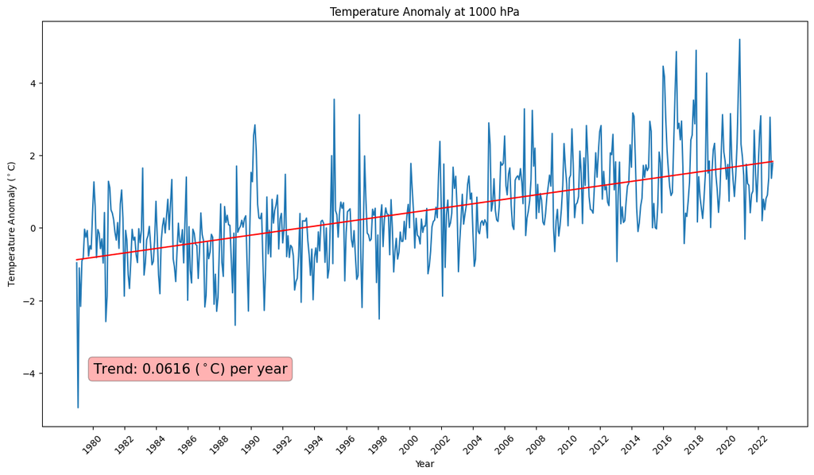

```python
#Get just anomaly data
anomdf = tdf[tdf["level"] == 1000]["anom"]
#Convert datetime into integer
years = anomdf.index.map(dt.datetime.toordinal)
fig, ax = plt.subplots(figsize= (15, 8))

plt.plot(years, anomdf.values)
reg = LinearRegression().fit(years.array.reshape(-1,1), anomdf.values)
plt.plot(years, years * reg.coef_ + reg.intercept_, color= "red")
plt.xticks(years[12::24], years[12::24].map(dt.datetime.fromordinal).year, rotation= 45)
plt.title("Temperature Anomaly at 1000 hPa")
plt.xlabel("Year")
plt.ylabel("Temperature Anomaly ($^\circ$C)")
plt.text(years[12], -4, "Trend: " + str(reg.coef_[0] * 365)[:6] + " ($^\circ$C) per year",
         bbox= dict(boxstyle= "round", facecolor= "red", alpha= .3), fontsize= 15)
plt.show()
```

The regresion model found that the surface temperature has been increasing by .06 degrees celcius for every year or .6 degrees per decade, which is much greater than the .18 degrees celcius per decade that NOAA has calculated the global temperature trend to be. This shows how global warming is affecting the polar regions more causing a larger effect which we can see in the Arctic sea ice.

Now that we understand these trends in sea ice lets see if we can fit a model to be able to predict September sea ice with data from earlier that year, so that predictions can be made each year. The first thing to do is to combine all of the data that we will use for the predictions into one DataFrame. We will use the climate indicies, SST, and temperature as parameters for the model. After combining all of the data we see that the regions from the SST dataset did not have data from 1979-1981. Since we don't have many years to train our model we can't just drop the years, so we will fill each of the regions missing data with the regions average.

```python
#Drop columns that aren't needed
tdf = tdf.drop(columns= ["t", "average"])
#Pivot dataframe so pressure levels are the columns
tdf = pd.pivot_table(tdf, values= "anom", index= "time", columns= "level")
icedf = icedf[["month", "extent", "year"]]

#We want to predict the extent in september
y = icedf[icedf["month"] == 9]
y = y[["extent"]].values[:]
y = y.ravel()
X = pd.concat([icedf, climatedf, tdf, sstregions], axis= 1)

#Look at only data from april to predict extent
X = X[X["month"] == 4]
#For each SST region fill in missing values with the average SST from that region
X["gin"] = X["gin"].fillna(X["gin"].mean())
X["barents"] = X["barents"].fillna(X["barents"].mean())
X["labrador"] = X["labrador"].fillna(X["labrador"].mean())
X["bering"] = X["bering"].fillna(X["bering"].mean())
#Drop the extent from the parameters
X = X.drop(columns = ["extent", "month"])
X.columns = X.columns.astype(str)

display(X.head())
```

|  | year | pna | wp | nao | soi | nina3.anom | censo | tna | tsa | whwp | ... | amon.us | qbo | 200.0 | 500.0 | 850.0 | 1000.0 | gin | barents | labrador | bering |
| --- | --- | --- | --- | --- | --- | --- | --- | --- | --- | --- | --- | --- | --- | --- | --- | --- | --- | --- | --- | --- | --- |
| 1979-04-01 | 1979.0 | -0.15 | 0.85 | -2.01 | -0.2 | 0.07 | 0.47 | 0.29 | 0.01 | -0.02 | ... | -0.250 | -3.57 | 2.585617 | -0.513748 | -2.009888 | -2.165036 | 3.093908 | 0.165798 | -0.438918 | -1.366165 |
| 1980-04-01 | 1980.0 | 1.66 | 0.72 | 1.26 | -1.0 | -0.20 | 0.86 | 0.56 | -0.11 | -0.13 | ... | -0.013 | 2.31 | 3.251221 | -0.033829 | -0.161224 | -0.819779 | 3.093908 | 0.165798 | -0.438918 | -1.366165 |
| 1981-04-01 | 1981.0 | -1.23 | 0.22 | 0.25 | -0.2 | -0.52 | 0.18 | 0.34 | -0.52 | -1.21 | ... | -0.103 | 8.28 | -0.765442 | 0.197891 | 0.385345 | 0.405033 | 3.093908 | 0.165798 | -0.438918 | -1.366165 |
| 1982-04-01 | 1982.0 | -2.08 | -0.52 | -0.04 | 0.1 | -0.01 | 0.47 | -0.16 | -0.35 | 0.67 | ... | -0.190 | -15.55 | 1.043594 | -0.399155 | -0.982605 | -1.288450 | 2.774699 | -0.455600 | -0.926949 | -1.280966 |
| 1983-04-01 | 1983.0 | 0.98 | 1.09 | -1.07 | -1.5 | 1.55 | 1.57 | 0.45 | -0.25 | 3.73 | ... | 0.051 | 13.81 | 1.976242 | -0.428345 | -1.393524 | -1.301256 | 2.779289 | 0.179925 | -0.937085 | -1.344360 |

5 rows × 25 columns

We will be creating a random forest regression model which creates many different decision trees that are trained on the data and each makes a seperate predition based on the input data, then a final prediction is calculated by averaging across all of the trees predictions. The algorithm is simple to use and it is robust to overfitting to the data because of the averaging across all trees which makes it great for our situation. Since the random forest creates a random set of descision trees the model will be different each time it's trained, causing different test scores. Lets average the scores over 50 different random forests to see how well our model is on average.

```python
#Arrays of each models training and test score
train = []
test = []

#Loop 50 times
for _ in range(50):
    #Split the training and test data randomly
    X_train, X_test, y_train, y_test = train_test_split(X, y, shuffle= True)
    scaler = StandardScaler()
    X_train_scaled = scaler.fit_transform(X_train)
    X_test_scaled = scaler.transform(X_test)
    #Create the model and fit the training data to it
    forest = RandomForestRegressor(max_features= 8, n_estimators= 300)
    forest.fit(X_train_scaled, y_train)

    #Add the training and test scores
    train.append(forest.score(X_train_scaled, y_train))
    test.append(forest.score(X_test_scaled, y_test))

#Display the averages
print("Average training score: ")
print(sum(train)/len(train))
print("Average test score: ")
print(sum(test)/len(test))
```

```
Average training score:
0.9669706695238185
Average test score:
0.7390768967828323
```

The average score on the testing data should be in the low to mid 70s. That's not that great, but there's more that we can do to try and raise that score. For the next part we will use random states which will guarentee the data is split and the model is fit in the same way which will make it easier to compare models to see improvements. Each feature in the model has a feature importance and it is a score of how informative each feature is to predicting sea ice. We can drop the features with minimal importance and see its effect on the model.

```
Training score:
0.9680108395288709
Test score:
0.7584762762853929
```

[figure not shown]

```python
#Split the data into training and test data
X_train, X_test, y_train, y_test = train_test_split(X, y, shuffle= True, random_state= 5)
#Create a scaler to preprocess the data
scaler = StandardScaler()
X_train_scaled = scaler.fit_transform(X_train)
X_test_scaled = scaler.transform(X_test)
#Make the model and fit the data
forest = RandomForestRegressor(max_features= 8, n_estimators= 300, random_state= 8)
forest.fit(X_train_scaled, y_train)
#Print out the scores
print("Training score: ")
print(forest.score(X_train_scaled, y_train))
print("Test score: ")
print(forest.score(X_test_scaled, y_test))
#Plot graph of the feature importances
plt.barh(X.columns, forest.feature_importances_)
plt.title("Random Forest Feature Importance")
plt.xlabel("Importance")
plt.ylabel("Feature Name")
plt.show()
```

```python
#Create Series of features and their importance
features = pd.Series(index= X.columns, data= forest.feature_importances_)
#Keep only features with importance greater than .02
features = features[features >= .025]
X = X[features.index]
#Split the data
X_train, X_test, y_train, y_test = train_test_split(X, y, shuffle= True, random_state= 5)
#Scale the data
X_train_scaled = scaler.fit_transform(X_train)
X_test_scaled = scaler.transform(X_test)
#Create model and fit it
forest = RandomForestRegressor(max_features= 8, n_estimators= 300, random_state= 8)
forest.fit(X_train_scaled, y_train)
#Print out the new scores
print("Training score updated: ")
print(forest.score(X_train_scaled, y_train))
print("Test score updated: ")
print(forest.score(X_test_scaled, y_test))
```

```
Training score updated:
0.9576075326879795
Test score updated:
0.8500588734565329
```

The new model increased its test score by almost 10 percent. Previously all of the different parameters added a lot of noise in the data most of which wasn't correlated to Arctic sea ice, by removing these parameters it simplifies our model and allows it to make better predictions. To get a better view of how the model is working we can plot it's predicted values against the actual values.

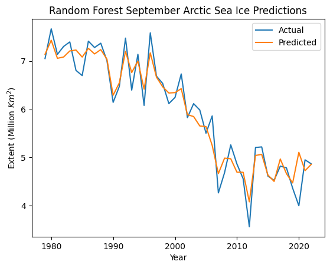

```python
X_scaled = scaler.transform(X)
predictions = forest.predict(X_scaled)
plt.plot(X["year"], y, label= "Actual")
plt.plot(X["year"], predictions, label= "Predicted")
plt.legend()
plt.xlabel("Year")
plt.ylabel("Extent (Million $Km^{2}$)")
plt.title("Random Forest September Arctic Sea Ice Predictions")
plt.show()
```

### Interpretation and Insight

The most important part of the data science lifecycle is the interpretation, and taking what we have learned from the data and applying it to the real world. Throughout this exploration of the Arctics sea ice extent, we have learned a couple of important facts. The temperature in the Arctic region has been increasing faster than in any other region. This warming has caused many changes in the region, specifically a loss in sea ice. The rapid decline of the Arctic sea ice causes a loss in habitat for many species and changes in global climate systems as fresh water from the ice enters the oceans, changing ocean currents and climate patterns. While climate change can be easily ignored since it doesn’t directly affect many people's lives that is why it’s important to look at the Arctic where climate change is drastically affecting it. More research and data are needed to keep improving our understanding of Arctic sea ice dynamics and better inform policies and actions aimed at mitigating the impacts of sea ice loss.